# Comparing clumping and LDSC results in UKBB GWAS

Gibran Hemani

03/10/2019

## Abstract

- When there are very few cases (e.g. <1000) there are no reliable top hits, and almost no evidence for any heritability. These traits comprise the majority (more than three quarters) of the ones analysed here. It’s probably not worth keeping these in the database.
- Removing top hits based on minor allele count seems to be a reasonable way to control false discoveries.
- There seems to be quite a lot of residual population structure which is not handled by the linear mixed model.

```r
library(knitr)
opts_chunk$set(warning=FALSE, message=FALSE, cache=TRUE, dev="png")

suppressWarnings(suppressPackageStartupMessages({
    library(tidyverse)
    library(TwoSampleMR)
    library(data.table)
}))

load("../results/collate.rdata")
ao <- available_outcomes(access_token=NULL)
ao$id <- gsub("UKB-b:", "UKB-b-", ao$id)
ao <- subset(ao, id %in% ldsc$id)
```

There are 20569 UKB traits that have been GWAS’d, but only 19538 are uploaded to the MR-Base database. The omitted ones are due to having low numbers of cases.

There are 1911008 total GWAS hits, after strict clumping.

The average number of hits per GWAS is:

```r
clumped %>%
group_by(id) %>%
summarise(n=n()) %>%
summarise(n=mean(n))
```

```
## # A tibble: 1 x 1
##       n
##   <dbl>
## 1  99.0
```

The top numbers are:

```r
nclumped <- clumped %>%
group_by(id) %>%
summarise(n=n()) %>%
arrange(desc(n))
head(nclumped, 10)
```

```
## # A tibble: 10 x 2
##    id              n
##    <chr>       <int>
##  1 UKB-b-2246   1275
##  2 UKB-b-3758   1227
##  3 UKB-b-15911  1199
##  4 UKB-b-8441   1199
##  5 UKB-b-13970   950
##  6 UKB-b-10787   773
##  7 UKB-b-10747   677
##  8 UKB-b-3123    663
##  9 UKB-b-14767   660
## 10 UKB-b-17235   654
```

Most of the top ones are excluded from the MR-Base upload:

```r
table(head(nclumped, 10)$id %in% ao$id)
```

```
##
## FALSE  TRUE
##     9     1
```

A bit strange.. let’s just discard ones that aren’t in MR-Base

```r
ldsc <- inner_join(ldsc, ao, "id")
dim(ldsc)
```

```
## [1] 19538    32
```

```r
dim(ao)
```

```
## [1] 19538    22
```

Let’s look at the types of traits.

```r
table(ldsc$category)
```

```
##
##              Binary Categorical Ordered          Continuous
##               18870                 412                 256
```

Almost everything is binary. What is the distribution of numbers of cases

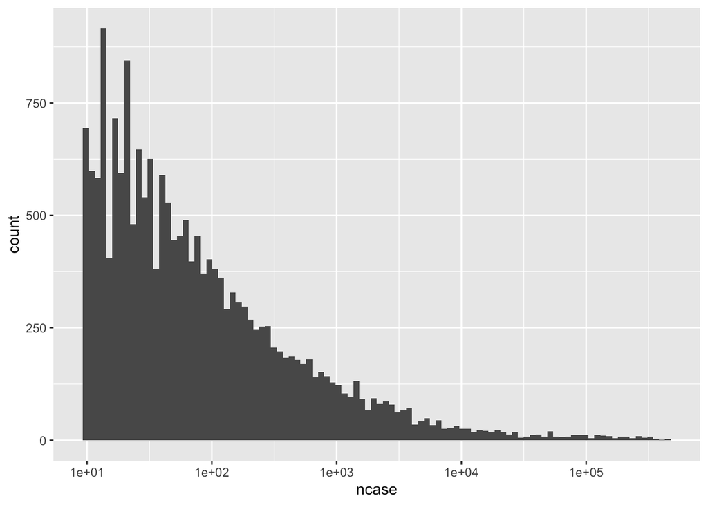

```r
ggplot(ldsc, aes(x=ncase)) +
geom_histogram(bins=100) +
scale_x_log10()
```

Most of these seem to be less than like 500 cases

```r
lapply(c(100,200,300,400,500,1000,5000,10000), function(x)
{
    filter(ldsc, category == "Binary") %>%
    summarise(count=sum(ncase < x)) %>%
    mutate(total=sum(ldsc$category=="Binary"), minimum_ncases=x) %>%
    select(minimum_ncases, total, count) %>%
    mutate(proportion=count/total)
}) %>% bind_rows %>% kable
```

| minimum_ncases | total | count | proportion |
| --- | --- | --- | --- |
| 100 | 18870 | 12126 | 0.6426073 |
| 200 | 18870 | 14222 | 0.7536831 |
| 300 | 18870 | 15160 | 0.8033916 |
| 400 | 18870 | 15686 | 0.8312666 |
| 500 | 18870 | 16053 | 0.8507154 |
| 1000 | 18870 | 17024 | 0.9021728 |
| 5000 | 18870 | 18240 | 0.9666137 |
| 10000 | 18870 | 18459 | 0.9782194 |

The vast majority of these have very small numbers of cases. How reliable are they? Compare the number of hits against h2 estimates from LDSC.

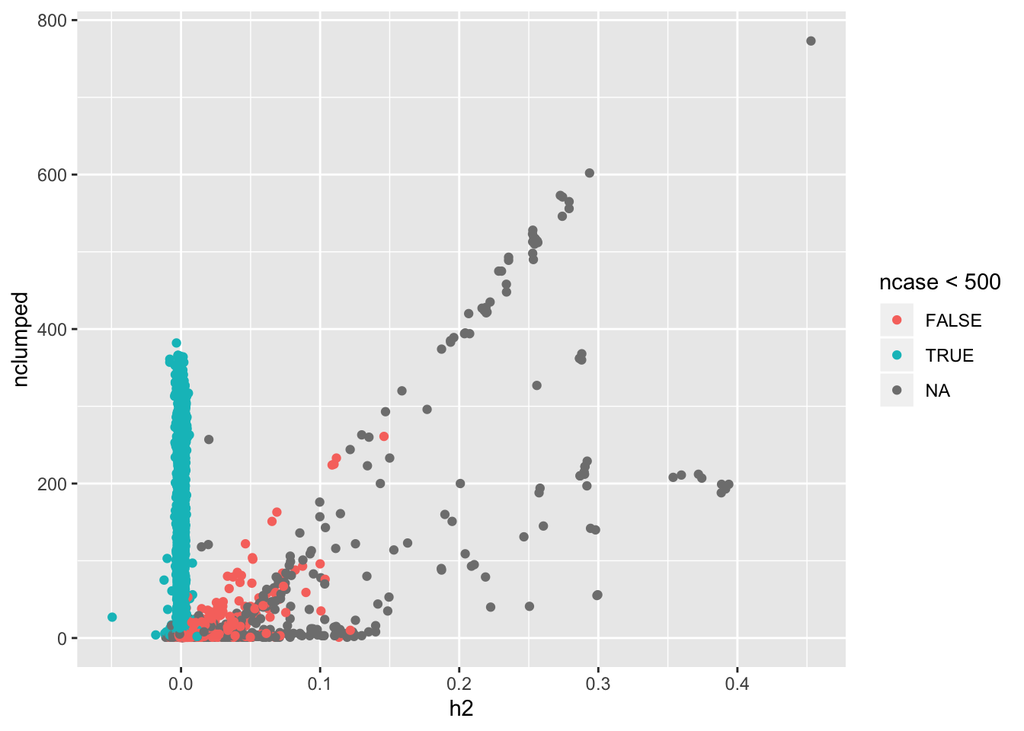

```r
ggplot(ldsc, aes(x=h2, y=nclumped)) +
geom_point(aes(colour=ncase < 500))
```

There is a large mass of associations that have 0 heritability but huge numbers of associations. These are all binary traits with fewer than 500 cases.

How many of the clumped hits are reliable?

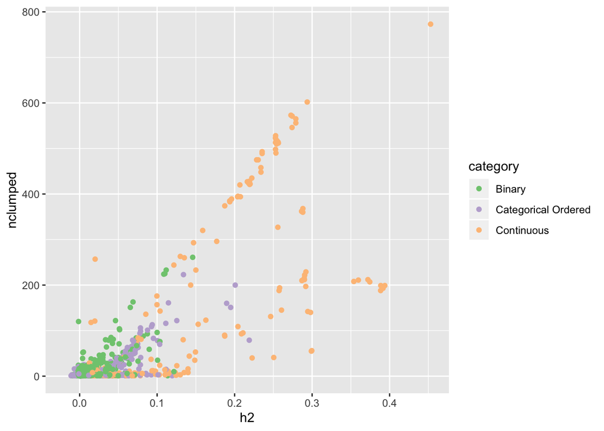

```r
ggplot(subset(ldsc, ncase > 500 | is.na(ncase)), aes(x=h2, y=nclumped)) +
geom_point(aes(colour=category)) +
scale_colour_brewer(type="qual")
```

Are any GWASs with ncase < 500 reliable? e.g. do any of them have significant h2?

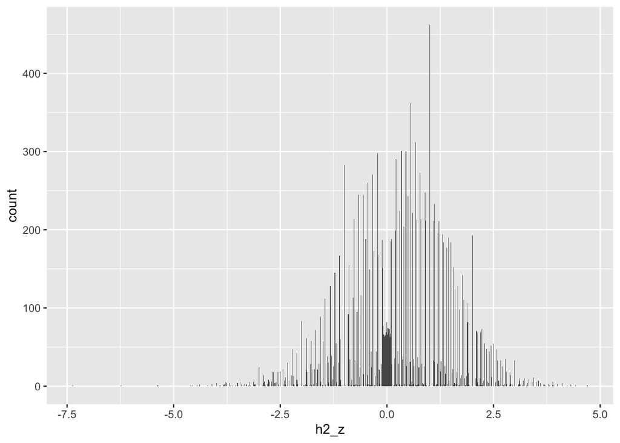

```r
filter(ldsc, ncase < 500) %>%
mutate(h2_z = h2 / h2_se) %>%
ggplot(., aes(x=h2_z)) +
geom_histogram(bins=1000)
```

There are as many ‘significant’ h2 estimates that are negative as there are that are positive. This suggests none of these are actually representing a signal at all. Check relationship with h2 and number of cases

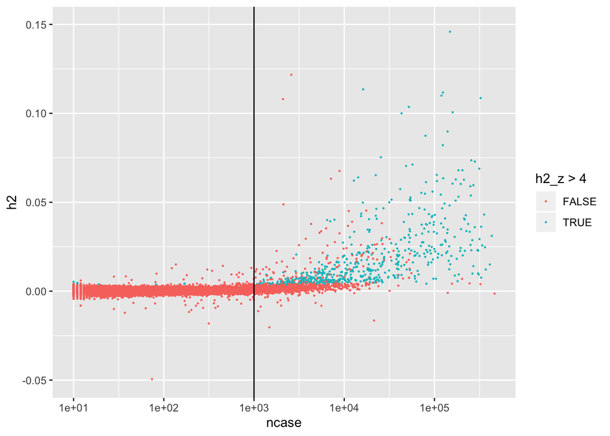

```r
ldsc %>%
mutate(h2_z = h2 / h2_se) %>%
ggplot(., aes(y=h2, x=ncase)) +
geom_point(aes(colour=h2_z > 4), size=0.2) +
scale_x_log10() +
ylim(c(-0.05,0.15)) +
geom_vline(xintercept=1000)
```

So, I think we could happily drop any study that has fewer than 1000 cases. Fewer than that and there is really no h2 signal. What’s left, if we keep only studies with more than 1000 cases?

```r
ldsc$keep <- ldsc$ncase > 1000 | is.na(ldsc$ncase)
table(subset(ldsc, keep)$category)
```

```
##
##              Binary Categorical Ordered          Continuous
##                1846                 412                 256
```

Write list of GWASs to keep

```r
write.table(subset(ldsc, keep)$id, file="ukb_id_keep.txt", row=F, col=F, qu=F)
```

## Minor allele count filters

Phil suggested having a minor allele count in cases cutoff of 90 for any GWAS signal. What does this look like for different MAF and number of cases?

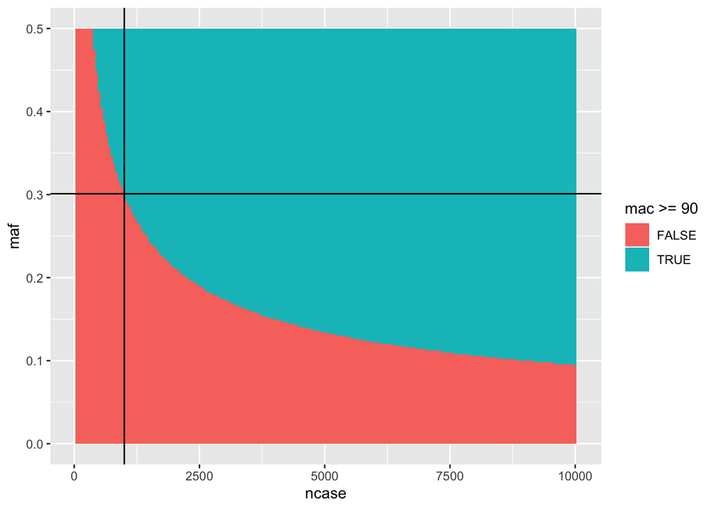

```r
param <- expand.grid(
    maf=seq(0.001,0.5,by=0.002),
    ncase=seq(50,10000,by=50)
)
param$mac <- param$maf^2 * param$ncase
ggplot(param, aes(x=ncase,y=maf)) +
geom_tile(aes(fill=mac>=90)) +
geom_vline(xintercept=1000) +
geom_hline(yintercept=min(subset(param, ncase==1000 & mac >= 90)$maf))
```

We’re looking at pretty strict thresholds when there are as few as 1000 cases. No GWAS hits allowed with MAF < 0.301.

## Filtering clumped hits based on MAC >= 90

Get allele frequencies for each SNP analysed:

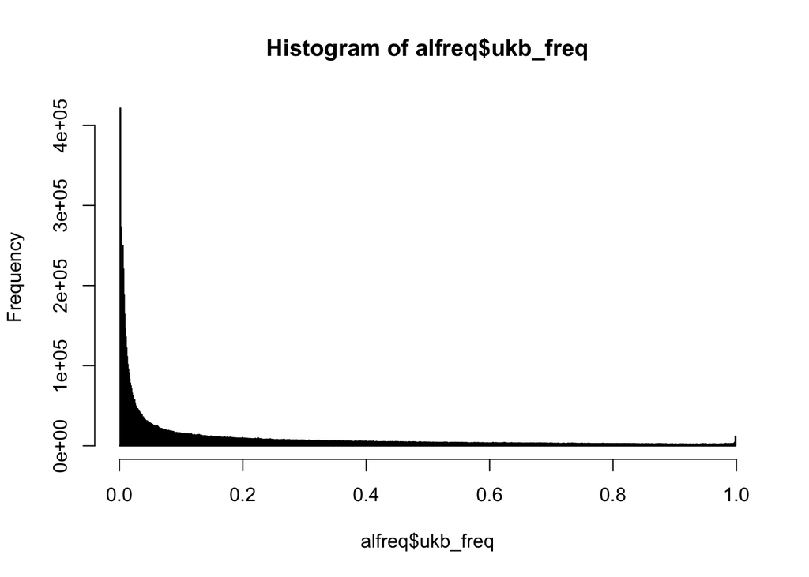

```r
alfreq <- fread("../data/ukbmaf.txt.gz")
names(alfreq) <- c("rsid", "ukb_freq")
hist(alfreq$ukb_freq, breaks=1000)
```

```r
table(duplicated(alfreq$rsid))
```

```
##
##   FALSE    TRUE
## 9837128   14738
```

```r
alfreq <- arrange(alfreq, ukb_freq) %>%
    filter(!duplicated(rsid))
alfreq$maf <- alfreq$ukb_freq
alfreq$maf[alfreq$maf > 0.5] <- 1 - alfreq$maf[alfreq$maf > 0.5]
```

Merge in alfreq and ncases

```r
clumped <- subset(clumped, id %in% ao$id)
clumped <- left_join(clumped, alfreq, by="rsid")


missingids <- ldsc$id[!ldsc$id %in% clumped$id]
ldsc$clumped_missing <- ldsc$id %in% missingids
table(subset(ldsc, clumped_missing)$category)
```

```
##
##              Binary Categorical Ordered          Continuous
##                 886                 168                  58
```

```r
index <- match(clumped$id, ao$id)
stopifnot(all(clumped$id == ao$id[index]))
clumped$ncase <- ao$ncase[index]
clumped$binary <- !is.na(clumped$ncase)
clumped$ncase[is.na(clumped$ncase)] <- ao$sample_size[index][is.na(clumped$ncase)]
clumped$mac <- clumped$maf^2 * clumped$ncase * 2 + 2 * clumped$maf * (1-clumped$maf) ** clumped$ncase
```

How many do we keep for different mac cutoffs?

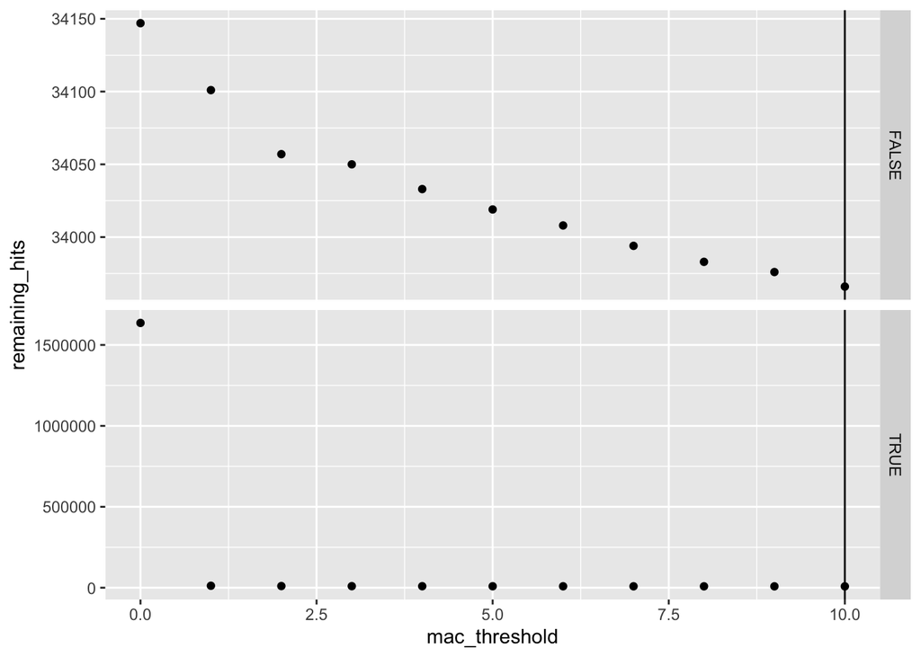

```r
temp <- expand.grid(mac_threshold = seq(0,10,by=1), binary=c(TRUE,FALSE)) %>%
    group_by(mac_threshold, binary) %>%
    summarise(remaining_hits = sum(clumped[clumped$binary == binary,]$mac > mac_threshold))
ggplot(temp, aes(x=mac_threshold, y=remaining_hits)) +
geom_point() +
geom_vline(xintercept=10) +
facet_grid(binary ~ ., scale="free_y")
```

There are 1623870 hits with expected mac < 1. So, that’s where the vast majority of hits are coming from. Remove those from the figure to see what the rest of the distribution looks like,

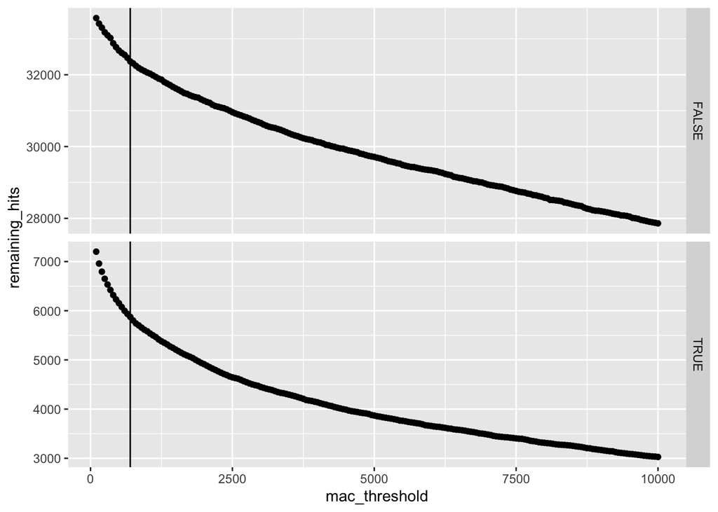

```r
temp <- expand.grid(mac_threshold = seq(100,10000,by=50), binary=c(TRUE,FALSE)) %>%
    group_by(mac_threshold, binary) %>%
    summarise(remaining_hits = sum(clumped[clumped$binary == binary,]$mac > mac_threshold))
ggplot(temp, aes(x=mac_threshold, y=remaining_hits)) +
geom_point() +
facet_grid(binary ~ ., scale="free_y") +
geom_vline(xintercept=700)
```

A higher threshold should reduce the possibility of false positives due to BoltLMM failure, but at what point are we throwing away too many? After that, there’s not an obvious cutoff in terms of number of associations when mac > 1 and mac > 10000. So, maybe take the threshold of mac > 700, that seems to be a point where the slope gets less steep??

This would leave 38246 GWAS hits.

What studies are coming up? e.g. how many cases in binary etc?

```r
clumped$keep <- clumped$mac > 700
nclumped <- clumped %>%
group_by(id) %>%
summarise(nclumped_mac10 = sum(keep))
ldsc <- left_join(ldsc, nclumped, by="id")
ldsc$nclumped_mac10[is.na(ldsc$nclumped_mac10)] <- 0
group_by(ldsc, category) %>%
summarise(studies_with_hits = sum(nclumped_mac10 > 0), studies_without_hits = sum(nclumped_mac10 == 0))
```

```
## # A tibble: 3 x 3
##   category            studies_with_hits studies_without_hits
##   <chr>                           <int>                <int>
## 1 Binary                            507                18363
## 2 Categorical Ordered               156                  256
## 3 Continuous                        189                   67
```

Relationship between number of hits and h2

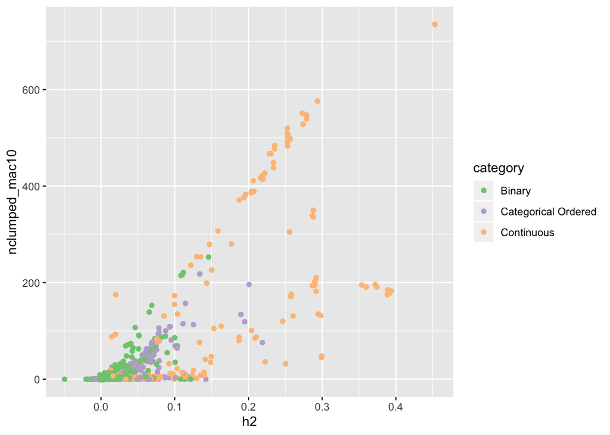

```r
ggplot(ldsc, aes(x=h2, y=nclumped_mac10)) +
geom_point(aes(colour=category)) +
scale_colour_brewer(type="qual")
```

## Population stratification

This is the distribution of h2 estimates based on LD score regression (LDSC):

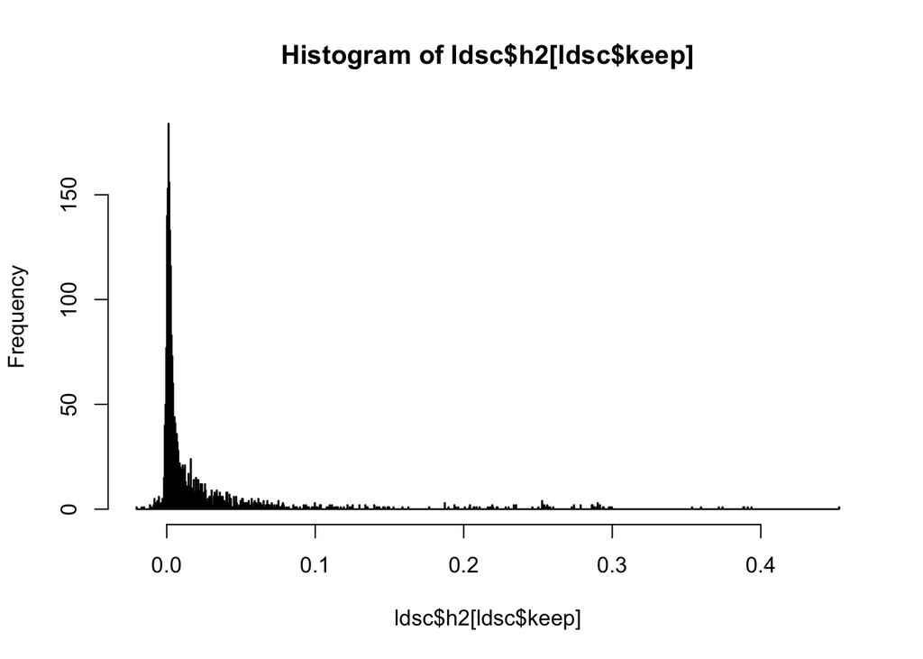

```r
hist(ldsc$h2[ldsc$keep], breaks=1000)
```

Distribution of intercept estimates (i.e. how much pop strat)

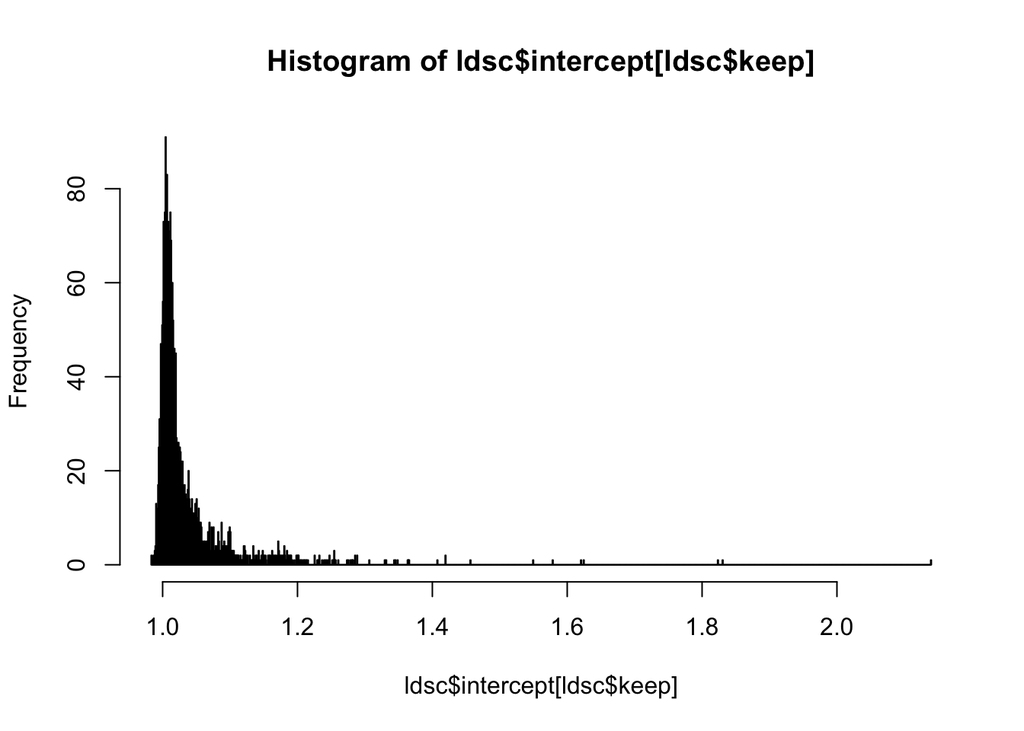

```r
hist(ldsc$intercept[ldsc$keep], breaks=1000)
```

Some of these are really large intercept values, what are they?

```r
ldsc %>%
arrange(desc(intercept)) %>%
select(id, trait, intercept, h2, nclumped_mac10) %>%
head(30) %>% kable
```

| id | trait | intercept | h2 | nclumped_mac10 |
| --- | --- | --- | --- | --- |
| UKB-b-1431 | Place of birth in UK - north co-ordinate | 2.1392 | 0.0200 | 175 |
| UKB-b-13231 | Place of birth in UK - east co-ordinate | 1.8309 | 0.0147 | 88 |
| UKB-b-4068 | Home location at assessment - north co-ordinate (rounded) | 1.8240 | 0.0196 | 93 |
| UKB-b-10787 | Standing height | 1.6249 | 0.4529 | 735 |
| UKB-b-6727 | Methods of discharge from hospital (recoded): Discharged on clinical advice/consent: From inpatient/daycase care | 1.6205 | 0.0049 | 13 |
| UKB-b-1666 | Home location at assessment - east co-ordinate (rounded) | 1.5789 | 0.0127 | 19 |
| UKB-b-5477 | Methods of admission to hospital (recoded): Elective admission | 1.5499 | 0.0041 | 10 |
| UKB-b-589 | Particulate matter air pollution (pm10); 2007 | 1.4568 | 0.0168 | 18 |
| UKB-b-16881 | Sitting height | 1.4200 | 0.2937 | 576 |
| UKB-b-13065 | Destinations on discharge from hospital (recoded): Usual Place of residence: Living with relatives | 1.4196 | 0.0038 | 5 |
| UKB-b-17289 | Sources of admission to hospital (recoded): Usual Place of residence: Living with relatives | 1.4077 | 0.0043 | 5 |
| UKB-b-7932 | PCT responsible for patient data: STOKE ON TRENT PCT | 1.3659 | 0.0026 | 1 |
| UKB-b-19641 | PCT where patients GP was registered: STOKE ON TRENT PCT | 1.3642 | 0.0026 | 1 |
| UKB-b-4540 | Methods of admission to hospital (recoded): Emergency admission: Non-injury | 1.3633 | 0.0041 | 2 |
| UKB-b-9568 | Number of blood samples taken | 1.3489 | 0.0027 | 1 |
| UKB-b-17409 | Trunk fat-free mass | 1.3452 | 0.2743 | 550 |
| UKB-b-9685 | Trunk predicted mass | 1.3431 | 0.2727 | 551 |
| UKB-b-13354 | Whole body fat-free mass | 1.3317 | 0.2790 | 539 |
| UKB-b-14540 | Whole body water mass | 1.3299 | 0.2790 | 547 |
| UKB-b-16446 | Basal metabolic rate | 1.3065 | 0.2741 | 528 |
| UKB-b-12828 | Leg fat-free mass (right) | 1.2888 | 0.2544 | 499 |
| UKB-b-14310 | Leg predicted mass (right) | 1.2882 | 0.2542 | 497 |
| UKB-b-9093 | Arm predicted mass (left) | 1.2856 | 0.2528 | 502 |
| UKB-b-19925 | Arm fat-free mass (left) | 1.2855 | 0.2535 | 507 |
| UKB-b-17271 | Leg predicted mass (left) | 1.2821 | 0.2561 | 499 |
| UKB-b-16099 | Leg fat-free mass (left) | 1.2813 | 0.2565 | 497 |
| UKB-b-16698 | Arm predicted mass (right) | 1.2806 | 0.2527 | 510 |
| UKB-b-14757 | PCT where patients GP was registered: NORTH STOKE PCT | 1.2786 | 0.0020 | 0 |
| UKB-b-19520 | Arm fat-free mass (right) | 1.2760 | 0.2547 | 500 |
| UKB-b-6987 | PCT where patients GP was registered: SOUTH STOKE PCT | 1.2736 | -0.0004 | 0 |

Plot of intercept against number of hits

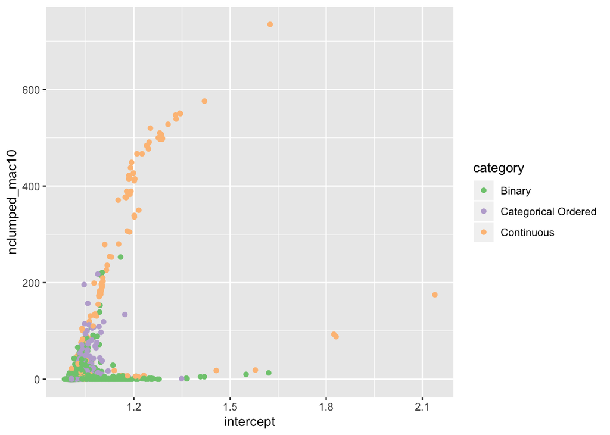

```r
ggplot(ldsc[ldsc$keep,], aes(x=intercept, y=nclumped_mac10)) +
geom_point(aes(colour=category)) +
scale_colour_brewer(type="qual")
```

Distribution of lambda values

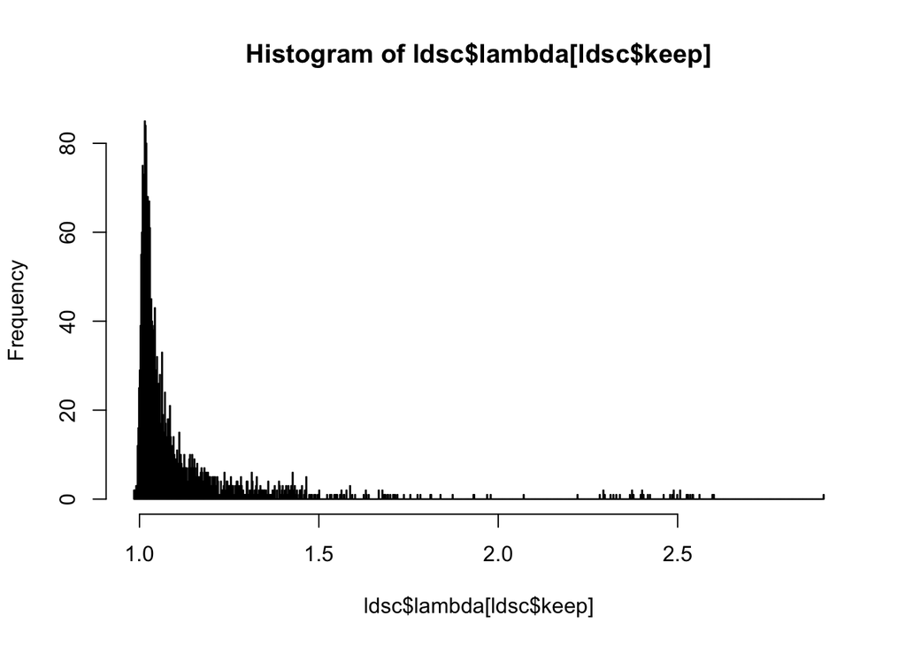

```r
hist(ldsc$lambda[ldsc$keep], breaks=1000)
```

Relationship of lambda and ldsc intercept

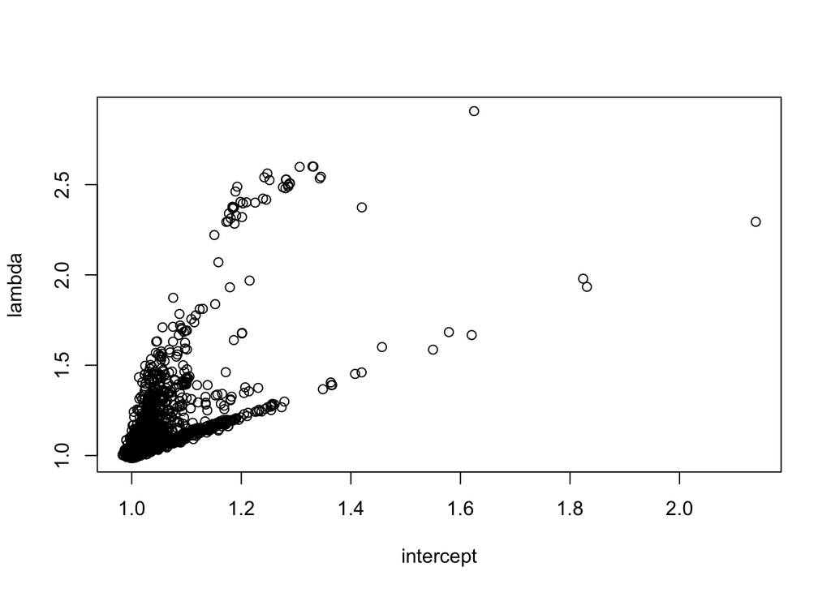

```r
plot(lambda ~ intercept, ldsc[ldsc$keep,])
```

It looks like there are two groups of traits which have high intercept / lambda

- those that are a mixture of biology and structure (e.g. height probably has bias due to assortative mating and dynastic effects etc)
- traits that relate to demography

Not sure what we can do about these. The ones related to structure are likely to be quite useful, e.g. as negative controls in MR. The height and BMI traits that have evidence of structure could be analysed using more robust methods e.g. within-family analysis.